# BIOS735 Final Project Report

Group 5: Ji-Eun Park, Yueqi Shen, Jianqiao Wang, Yangjianchen Xu, Christina Zhou, Haotian Zou

4/27/2020

# Introduction

Data does not always fall in clear-cut categories that fit pre-specified models. For example, collected data could be longitudinal and time-to-event. It would be inaccurate to only fit a longitudinal model or only fit a survival model. Previous studies (Ye at al, 2017) have shown that the two-step approach may reduce efficacy which in turn inflates standard errors of estimates, thus a joint model may be preferred to a two-step approach. For joint modeling, previous literature (Serrat et al, 2015) suggests that Bayesian methods are efficient and computationally easier. In the history of statistics, an interest in comparing frequentist versus Bayesian methods has been prominent. Thus, for our project, we aim to analyze data using a joint model approach to compare frequentist, Bayesian, and machine learning methods.

## Dataset

For our project, we examined the `aids` dataset, which can be found in the JM package in R. This data is from a randomized clinical trial (RCT) examining two treatments in HIV patients. It contains both longitudinal and survival data on 467 patients who failed or were intolerant of zidovudine (AZT) therapy. These treatment groups of the RCT are two anti-retroviral drugs: zalcitabine and didanosine. The dataset contains a total of 1405 observations and 9 variables: patient identifier, time to death or censoring, death indicator, CD4 cell count, time points at which the CD4 cells count were recorded, treatment indicator, gender indicator, previous opportunistic infection (AIDS diagnosis) at study entry indicator, and AZT tolerance indicator. This data was already processed and cleaned, so we did not need to perform data cleaning.

The HIV virus kills CD4 cells, which has a normal range of about 500 to 1500 cells. Thus, the CD4 cell count decreases as HIV infection progresses. A person is diagnosed with AIDS when the CD4 count drops below 200 cells. Thus, a typical outcome of interest for an AIDS study is the CD4 cell count, and monitoring the count over time is common. The standard transformation of CD4 count is the square root transformation (for normality distribution), which was already applied in the `aids` dataset. We present descriptive statistics of these variables in our Results section below.

## Project Objectives

(1). To assess the association between CD4 cell count with time, adjusting for other covariates such as observed time of CD4 cell count, treatment drug, indicator of previous opportunistic infection (AIDS diagnosis) at study entry, and AZT tolerance status.

(2). To use the joint model to assess the association between survival outcome (death status and event time) with the drug efficacy and the latent mean of CD4 count at event time.

(3). To assess and compare the model fitting result (mean and standard error) for the frequentist and Bayesian methods, as well a machine learning methods. We also simulated similar data to check and compare the model fitting results.

(4). To propose a dynamic prediction framework to patients with longitudinal outcomes available, such as predicting the future longitudinal outcome and conditional survival probability at a given time.

# Methods

Since this dataset contains both longitudinal and survival data, we proposed a joint model to simultaneously capture the random effects from the longitudinal data and to estimate the parameters of the survival model. We compare frequentist methods to Bayesian methods by performing analysis on aims with Monte-Carlo EM (MCEM), Bayesian methods, and finally random survival forest (RSF) to compare to machine learning methods as well. We are interested in seeing the accuracy and differences of these methods as well as computational speed.

In the sections below, we describe in detail our model and methods.

### Model specification

Joint modeling framework:
$$Y_{ij} = m_i(t_{ij}) + \epsilon_{ij}$$

$$h_i(t) = h_0(t)\exp(\boldsymbol{w_i'}\boldsymbol{\gamma} + \alpha m_i(t))$$

where $m_i(t_{ij}) = \beta_0 + \beta_1 t_{ij} + \boldsymbol{x_{ij}}' \boldsymbol{\beta} + u_i$, and $m_i(T_i) = \beta_0 + \beta_1 T_i + \boldsymbol{x_i'^{(T_i)}} \boldsymbol{\beta^{(t)}} + u_i$.

We have $i=1,2, \dots, n$ subjects, $j = 1, 2,\dots, J_i$ visits for each subject. We observe the longitudinal outcome $Y_{ij}$ for subject i at visit j, and we observe the patient’s covariate $\boldsymbol{x_{ij}}$ at time $t_{ij}$ . We also observe the event time $T_i = \text{min}(T_i^*, C_i)$, where $T_i^*$ is the actual failure time, and $C_i$ is the censoring time. We also observe the event indicator $\delta_i = I(T_i^*\leq C_i)$, and covariates for survival data $\boldsymbol{w_i}$ for patient $i$. When $\delta_i = 1$, the event occurred. When $_i = 0 $, the patient was censored.

Here, $m_i(t_{ij})$ is the latent longitudinal mean at time $t_{ij}$, and $u_i$ is the random effect for each subject $i$. And $h_i(t)$ is the hazard function for subject $i$ at time $t$, and $h_0$ is the baseline hazard function.

Assumptions:

- $u_i \sim N(0, \sigma_u^2)$;
- $\epsilon_{ij} \sim N(0, \sigma_e^2)$;
- $Y_{ij} |u_i \perp Y_{ij'}|u_i$;
- $T_i^* \perp C_i$;
- $\{T_i, \delta_i \} | u_i \perp Y_{ij} | u_i$.

### Likelihood

We write the parameter space $\boldsymbol{\theta} = (\beta_0, \beta_1, \boldsymbol{\beta}, \sigma_u, \sigma_e, \boldsymbol{\gamma}, \alpha)'$. For simplicity of estimation, we posit a constant baseline hazard function $h_0$.

We write the full data likelihood:
$$L(\boldsymbol{\theta} | Y, T) = \prod_{i=1}^n \int_{-\infty}^{\infty} [\prod_{j=1}^{J_i} f(Y_{ij} | \beta, u_i)] [h_i(T_i)^{\delta_i} S_i(T_i)] f(u_i|\sigma_u^2) du$$

We write the complete data likelihood (assume random effect is known):
$$L_C(\boldsymbol{\theta} | Y, T) = \prod_{i=1}^n [\prod_{j=1}^{J_i} f(Y_{ij} | \beta, u_i)] [h_i(T_i)^{\delta_i} S_i(T_i)] f(u_i|\sigma_u^2)$$

We can write the complete data likelihood in Bayesian perspective:
$$L_B(\boldsymbol{\theta} | Y, T) = \prod_{i=1}^n [\prod_{j=1}^{J_i} f(Y_{ij} | \beta, u_i)] [h_i(T_i)^{\delta_i} S_i(T_i)] f(u_i|\sigma_u^2) P(\boldsymbol{\theta})$$

where we denote $P(\boldsymbol{\theta})$ as the prior distribution of $\boldsymbol{\theta}$.

### Dynamic prediction

Suppose for a new subject $i'$, and we observe his longitudinal outcomes and covariates up to time $T$, where $j_{i'}$ is the number of visits up to time $T$ for subject $i'$. We want to predict his future longitudinal outcomes, and survival probability at time $T'$.

We can sample the random effect for the subject $i'$ based on its posterior distribution:
$$P(u_{i'} | Y_{i'}^{(T)}, T_{i'}>T, \boldsymbol{\hat \theta}) \propto \prod_{j=1}^{j_{i'}} f(Y_{i'j} |u_i', \boldsymbol{\hat \theta}) P(T_{i'}>T | u_{i'}, \boldsymbol{\hat \theta}) f(u_{i'} | \boldsymbol{\hat \theta})$$

We sample from the above distribution, using Metropolis Hastings algorithm with random walk.

Suppose we have M samples of $u_{i'}$, we can then predict the future longitudinal outcome at time $T'$, and conditional survival probability at time $T'$, as:

$$m_{i'}(T') = \hat \beta_0 + \hat \beta_1 T' + \boldsymbol{x_{i'j}'} \boldsymbol{\hat \beta} + u_{i'}^{(d)}$$

$$P(T_{i'}>T' | T_{i'}>T) = S_{i'}(T' | \boldsymbol{\hat \theta}, u_{i'}^{(d)})/S_{i'}(T | \boldsymbol{\hat \theta}, u_{i'}^{(d)})$$

We can calculate the area under curve (AUC) and Brier Score (BS) to compare the prediction accuracy. We will compare the model estimates, standard error, computation speed, and prediction accuracy. We used cross-validation with 3:1 ratio to check prediction accuracy.

# Details in methods

We used MCEM algorithm, Bayesian methods, and Random Survival Forest to estimate parameters.

### MCEM algorithm

First, suppose we have the parameter estimate at iteration $t$. We sample the random effect $u_i$ from the posterior distribution of $u_i$, and do the maximization step.

We propose the Q-function as:

$$Q(Y|\theta^{(t)}) = E(l_c(\theta^{(t)}|Y, T)) = \sum_{i=1}^n \int l_i(\theta | Y_i, T_i) f(u_i | \theta^{(t)}, Y_i, T_i) du$$

where
$$l_i(\theta | Y_i, T_i) = \sum_{j=1}^{J_i} \log P(Y_{ij}|\theta, u_i) + \log[h_i(T_i)^{\delta_i}S_i(T_i)] + \log P(u_i |\theta)$$
,

$$f(u_i | \theta^{(t)}, Y_i, T_i) \propto \prod_{j=1}^{j_i} P(Y_{ij} |u_i, \boldsymbol{\theta^{(t)}}) h_i(T_i | \theta^{(t)})^{\delta_i}S_i(T_i | \theta^{(t)}) P(u_{i} | \boldsymbol{ \theta^{(t)}})$$
.

We used the Metropolis Hastings Algorithm with a random walk to draw the samples of random effect and calculate the integral by Monte Carlo method.

After we sample $M$ random effect for each subject, we get the augmented longitudinal dataset and survival dataset.

Second, we calculate $\sigma_u^{(t+1)} = \text{SD}(\boldsymbol{u})$, where $\boldsymbol{u}$ is a vector of random effects for all subjects. We calculate $\sigma_e^{(t+1)}$ by simply fitting a linear model using augmented longitudinal dataset, treating $\boldsymbol{u}$ as the offset.

Third, for maximization of $(\beta_0, \beta_1, \boldsymbol{\beta}, \log(h_0))$, we used MH algorithm with RW to sample from the log likelihood given $\sigma_u^{(t+1)}$, $\sigma_e^{(t+1)}$, $\gamma^{(t)}$, $\alpha^{(t)}$.

Finally, for maximization $\gamma, \alpha$, we fit a Cox proportional hazards model, using the augmented survival dataset, given $\log(h_0)^{(t+1)}$, $m_i(T_i)^{(t+1), m}$, where $m_i(T_i)^{(t+1), m} = \beta_0^{(t+1)} + \beta_1^{(t+1)}T_i + \boldsymbol{x_i'^{(T_i)}} \boldsymbol{\beta^{(t)}} + u_i^{m}$, and $u_i^{m}$ denotes the $m^{th}$ random effect for subject $i$.

### Bayesian methods

We used Stan to perform sampling, where We used No-U-Turn Sampler (NUTS), based on Hamiltonian Monte Carlo (HMC).

We used normal prior distributions for $\beta$…, and inverse Gamma prior distributions for the variance parameters. We used the following prior distribution for the parameters for Bayesian methods:

1. $\beta \sim N(0, 10^2)$.
2. $\log(h_0) \sim N(0, 10^2)$.
3. $\gamma \sim N(0, 10^2)$.
4. $\alpha \sim N(0, 10^2)$.
5. $\sigma_u \sim \text{Inverse Gamma}(0.1, 0.1)$.
6. $\sigma_e \sim \text{Inverse Gamma}(0.1, 0.1)$.

### Initial value specification

Good initial values will accelerate the convergence speed for both EM algorithm and Bayesian methods.

To get initial values of $\beta_0, \beta_1, \boldsymbol{\beta}, \sigma_u, \sigma_e$, we fit a linear mixed effects model, and extract the estimated coefficients and variance components.

To get initial values of $\log(h_0), \gamma, \alpha$, we fit an AFT model with exponential distribution, where the latent longitudinal mean is calculated at the event time for each subject. We extract the estimated intercept and coefficients, and take negative as initial values of $\log(h_0), \gamma, \alpha$.

### Random Survival Forest

For machine learning methods, we used the random survival forest (RSF), considering only for the survival model, and ignoring the longitudinal model, where We used the CD4 count nearest to survival time as the substitute of latent longitudinal mean.

For the random survival forest, we used our function `RandomSurvivalForest`. This function `rfsrc` from the r package `randomForestSRC`, allows random forest for right-censored survival.

Here we used the log-rank test to grow survival trees. In our dataset, we split each tree at $x\le c$ and $x>c$ where x is CD4 cell count and drug didanosine (ddI). Since we only use 2 variables, each split depends on one variable. Such a split defines left($x\le c$) and right($x>c$) daughter membership. Each split maximizes survival differences between the two nodes. Let $t_1<t_2<\dots<t_m$ be the distinct times of `death` in the parent node $h$, and for each left and right node, we get the number of deaths ($d_{k,l}$, $d_{k,r}$ where l=left, r=right) and patients at risk respectively at time $t_k$ $(Y_{k,l}$,$Y_{k,r})$.

$$Y_{k,l} = \#\{i:T_i \ge t_k, x_i \le c\},\quad Y_{k,r} = \#\{i:T_i \ge t_k, x_i > c\}$$

The log-rank test for each split at value $c$ for a variable $x$ is
$$L(x,c) = \frac{\sum\limits_{k=1}^{m} (d_{k,l} - Y_{k,l}\frac{d_k}{Y_k})}{\sqrt{\sum\limits_{k=1}^m \frac{Y_{k,l}}{Y_k} (1-\frac{Y_{k,l}}{Y_k}) (\frac{Y_k-d_k}{Y_k-1}) d_k}}$$

We find the c such that maximizes $|L(x,c)|$, which means the differences between the two nodes are maximized.

# Data simulation

In order to check our methods work, we simulated data to test our package. Our simulation set-up is as follows:

First, we simulated the longitudinal responses using the following formula: $Y_{ij} = 20 + (-1)*t_{ij} + (-4)*x_i + u_i + \epsilon_{ij}$, where $u_i \sim N(0, 4), \epsilon_{ij} \sim N(0, 1), x_i \sim \text{binom}(1, 0.4)$, for subject $i$ at time point $j$ where $i = 1,\dots,N$ and $j = 0,2,6,12,18$.

Next, we simulated N random uniform distributions to correspond with the survival probabilities $S(T)$. We used the relation between $S(T_i)$ and the hazard to calculate the survival time. The hazard is defined as: $h_i(T_i) = \exp(-2) \exp(-1*w_i + (-0.2)*m_i(T_i))$, where $w_i$ corresponds to the drug variable in the `aids` dataset and $w_i \sim \text{binom}(1, 0.5), m_i(T_i) = 20 + (-1)*T_i + (-4)*x_i + u_i$. We calculated the survival time $T_i^*$ using following formula:

$$S_i(t) = \exp(-\int_0^t h_i(t) dt) = \exp\{-h_0\exp[w_i \gamma + \alpha(\beta_0 + \beta_2x_i + u_i)] \frac{\exp(\alpha \beta_1 t) - 1}{(\alpha \beta_1)}$$

Thus, we see that $T_i^* =\frac{1}{\alpha\beta_1}log[1-\frac{\alpha\beta_1\log(S_i(t))}{h_0\exp(\gamma w_i+\alpha(\beta_0+\beta_2x_i+u_i))}]$, where $\alpha = -0.2, \beta_0 = 20,\beta_1 = -1,\beta_2 = -4,\gamma = -1, h_0 = \exp(-2)$.

In order to obtain a death rate close to that of the `aids` dataset ($40.25\%$), we simulated the censoring indicator for each individual from a random Uniform distribution, $C_i \sim Unif(0,27)$. We define the time to event as $T_i = min(T_i^*, C_i)$. Finally, we define our death indicator as $\delta_i = I(T_i^* \le C_i)$.

For each simulation, we produce two sets of joint data: one longitudinal dataset and one survival dataset. The survival dataset consists of one row per subject with variables time to event, death indicator, and treatment group (drug). The longitudinal dataset consists of multiple observations per subject with variables response, observed time, and covariates. Subjects do not have observation times beyond the event time.

We simulated datasets of 700 subjects, with 500 subjects for the training dataset and 200 subjects for the testing dataset.

# Software implementation

We write our package `jm5`. Here are the main functions:

```r
jm_filter <- function(l.formula, s.formula, dat, ID){}

MCEM <- function(l.formula, s.formula, long.dat, surv.dat,
                 max.iter = 30, tol = 1e-3, seed = 123,
                 progress = TRUE){}

fit_stan <- function(l.formula, s.formula, long.dat, surv.dat,
                     n.iter = 2000,
                     n.burnin = floor(n.iter/2),
                     seed = 123,
                     progress = TRUE){}

RandomSurvivalForest = function(surv.dat, s.formula, ntree=100,seed=12,...)  {}

create_cv <- function(long.dat, surv.dat, ratio = 3, reps = 10, seed = 123){}

calc_AUC_BS <- function(l.formula, s.formula, long.test, surv.test,
                        Tstart, Tstop, summary.mean, seed = 123){}

calc_AUC_BS_RSF <- function(surv.test2, Tstart, Tstop, res){}

SimulateDataset = function(n.train = 500, n.test = 200, seed){}

sim.MCEM = function(sim.num = 10, max.iter = 30, tol = 1e-3, seed = 123, progress = TRUE){}

sim.Bayesian = function(sim.num = 10, n.iter = 2000, n.burnin = floor(n.iter/2), seed = 123, progress = TRUE){}
```

# Results

We first load our R package, `jm5`. We want to separate the `aids` dataset into its corresponding longitudinal and survival components.

### Load our `jm5` package; separate `aids` dataset

```r
library(tidyverse)
library(knitr)
library(devtools)
load_all('jm5')
```

In accordance with our first two objectives, we define our longitudinal formula and survival formula, and create two separate longitudinal and survival datasets.

```r
l.formula <- CD4 ~ obstime + drug + prevOI + AZT
s.formula <- Surv(Time, death) ~ drug
dat <- JM::aids
l <- jm_filter(l.formula, s.formula, dat, ID = dat$patient)
long.dat <- l[[1]]
surv.dat <- l[[2]]
```

Below are the top 6 observations of the longitudinal and survival datasets.

```r
kable(head(long.dat), caption = "First 6 observations of longitudinal AIDS dataset")
```

First 6 observations of longitudinal AIDS dataset

| CD4 | obstime | drugddI | prevOIAIDS | AZTfailure | ID |
| --- | --- | --- | --- | --- | --- |
| 10.677078 | 0 | 0 | 1 | 0 | 1 |
| 8.426150 | 6 | 0 | 1 | 0 | 1 |
| 9.433981 | 12 | 0 | 1 | 0 | 1 |
| 6.324555 | 0 | 1 | 0 | 0 | 2 |
| 8.124038 | 6 | 1 | 0 | 0 | 2 |
| 4.582576 | 12 | 1 | 0 | 0 | 2 |

```r
kable(head(surv.dat), caption = "First 6 observations of survival AIDS dataset")
```

First 6 observations of survival AIDS dataset

|  | Time | death | drugddI | ID |
| --- | --- | --- | --- | --- |
| 1 | 16.97 | 0 | 0 | 1 |
| 4 | 19.00 | 0 | 1 | 2 |
| 8 | 18.53 | 1 | 1 | 3 |
| 11 | 12.70 | 0 | 0 | 4 |
| 15 | 15.13 | 0 | 1 | 5 |
| 19 | 1.90 | 1 | 0 | 6 |

### Summary statistics for `aids` dataset

| Variable | Description |
| --- | --- |
| ID | Patients identifier (1-467) |
| Time | The time to death or censoring |
| death | 0 for censoring, 1 for death |
| CD4 | The CD4 cells count |
| obstime | The time points at which the CD4 cells count was recorded (0, 2, 6, 12, 18) |
| drug | ddI (1) for didanosine, ddC (0) for zalcitabine |
| prevOI | AIDS (1) for previous opportunistic infection, noAIDS (0) for no previous infection |
| AZT | failure (1) for AZT failure, intolerance (0) for AZT intolerance |
| gender | 1 for male, 0 for female |

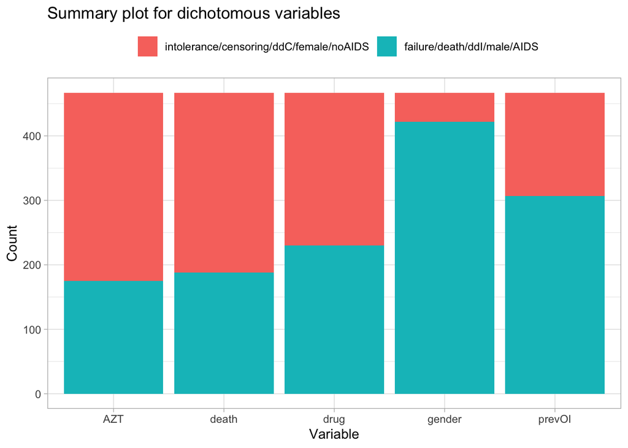

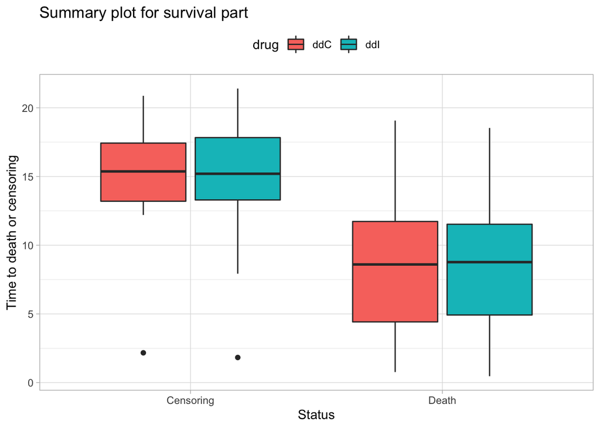

Since more than 90% of subjects are male, we do not include the gender covariate for the first aim. The gender inbalance leads to power loss when estimating the gender coefficient. We can see that the other variables are relatively balanced.

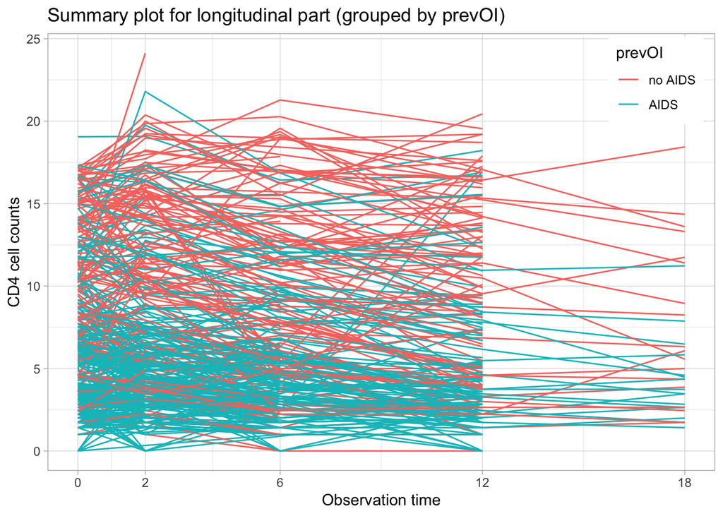

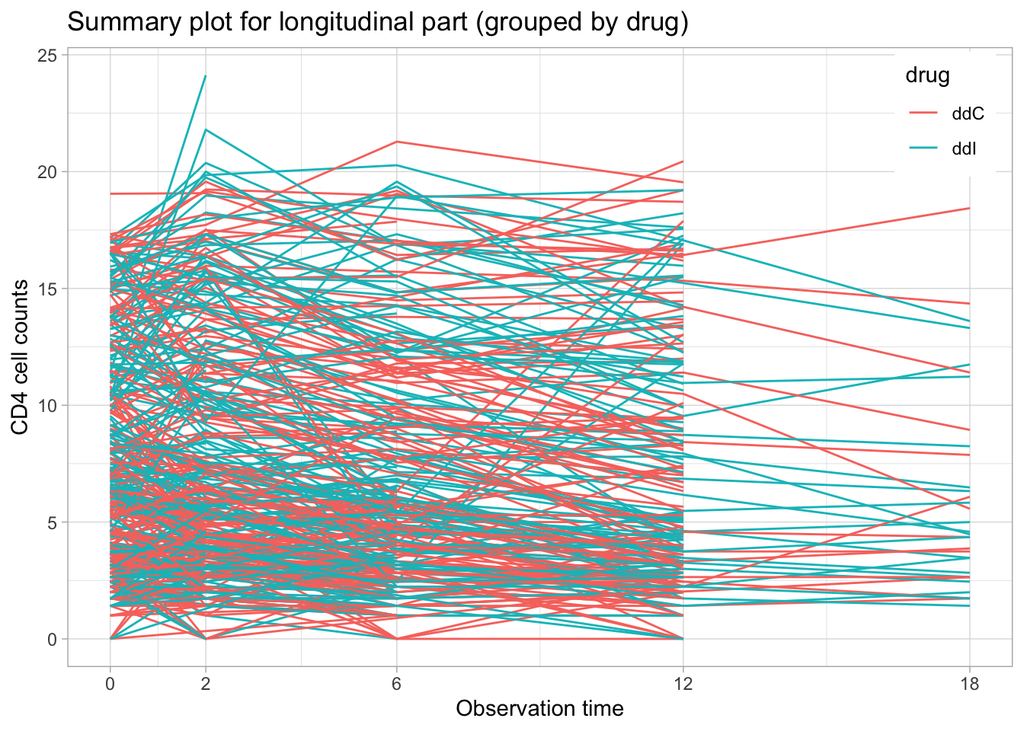

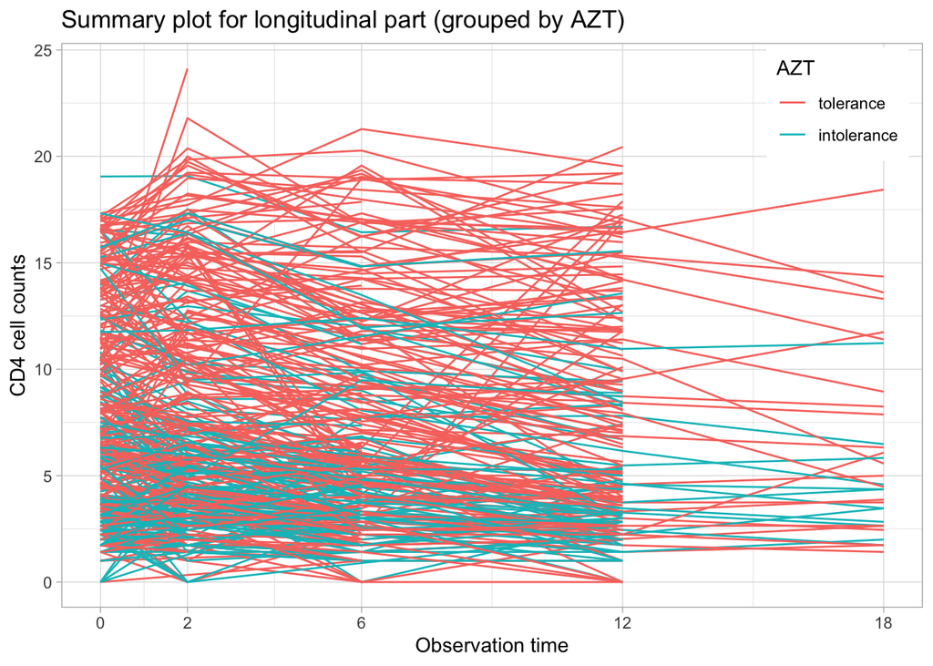

The spaghetti plots presented here show the progression of CD4 cell count over time grouped by different variables. We note that most subjects only have observation times to month 12.

### Model fit for `aids` dataset - MCEM algorithm

```r
l.formula2 <- CD4 ~ obstime + drugddI + prevOIAIDS + AZTfailure
s.formula2 <- Surv(Time, death) ~ drugddI

start = Sys.time()
mcem.result <- MCEM(l.formula2, s.formula2, long.dat, surv.dat, max.iter = 10)
end = Sys.time()
time_mcem1 = end - start
```

We now fit the MCEM algorithm for the `aids` dataset. This method took 12.75 minutes to run. Our parameter estimates of $\boldsymbol{\theta} = (\beta_0, \beta_1, \boldsymbol{\beta}, \sigma_u, \sigma_e, \boldsymbol{\gamma}, \alpha)'$ are summarized in the table below.

Model Fitting Results from MCEM

| beta0 | beta1 | beta1 | beta2 | beta3 | sigma_u | sigma_e | logh0 | gamma | alpha |
| --- | --- | --- | --- | --- | --- | --- | --- | --- | --- |
| 10.10486 | -0.1528178 | 0.4450007 | -4.619871 | -0.2789507 | 4.319185 | 2.162698 | -2.19499 | 0.2934648 | -0.298038 |

It is time-consuming to run MCEM and each iteration takes more than 1 minute. Although the algorithm is hard to converge and we only run 10 iterations, the estimates are still similar with the estimates given by Bayesian method below.

### Model fit for `aids` dataset - Bayesian method

```r
start = Sys.time()
fit.result <- fit_stan(l.formula2, s.formula2, long.dat, surv.dat)
end = Sys.time()
time_bayes1 = end - start
```

Meanwhile, using the Bayesian method on the `aids` dataset, we obtained our parameter estimates in only 7.96 minutes. This is 4.7979326 minutes faster than MCEM. Our parameter estimates of are summarized in the table below.

Model Fitting Results from Bayesian

|  | mean | se_mean | sd | 2.5% | 25% | 50% | 75% | 97.5% |
| --- | --- | --- | --- | --- | --- | --- | --- | --- |
| beta[1] | 10.1703047 | 0.0148184 | 0.3790635 | 9.4280749 | 9.9127259 | 10.1686157 | 10.4245839 | 10.9081694 |
| beta[2] | -0.1702523 | 0.0001453 | 0.0121049 | -0.1940049 | -0.1783613 | -0.1703323 | -0.1621407 | -0.1459065 |
| beta[3] | 0.4454401 | 0.0141128 | 0.3903131 | -0.3221580 | 0.1881520 | 0.4423813 | 0.7122643 | 1.1983356 |
| beta[4] | -4.7050497 | 0.0183989 | 0.4919912 | -5.6768878 | -5.0276076 | -4.7005868 | -4.3702675 | -3.7416689 |
| beta[5] | -0.3117746 | 0.0157125 | 0.4743845 | -1.2699608 | -0.6307682 | -0.3009815 | 0.0160387 | 0.5979937 |
| sigma_u | 3.9266869 | 0.0017300 | 0.1439028 | 3.6648173 | 3.8295144 | 3.9210623 | 4.0229798 | 4.2199019 |
| sigma_e | 1.9633914 | 0.0007734 | 0.0457932 | 1.8754134 | 1.9324350 | 1.9621442 | 1.9948414 | 2.0550836 |
| logh0 | -2.3438456 | 0.0023125 | 0.1553748 | -2.6487118 | -2.4455380 | -2.3422137 | -2.2374944 | -2.0405181 |
| gamma[1] | 0.3140991 | 0.0019309 | 0.1501852 | 0.0203615 | 0.2129078 | 0.3115084 | 0.4192872 | 0.6001124 |
| alpha | -0.2792813 | 0.0005011 | 0.0330735 | -0.3462728 | -0.3012618 | -0.2789007 | -0.2565877 | -0.2168081 |

It is easy to implement Bayesian method in Stan. Since we got the posterior distributions of the parameters, we can easily obtain the estimates and corresponding 95% credible intervals, which gave similar results with MCEM method.

### Random Survival Forest for `aids` dataset

For Random Survival Forest (RSF), since we used the CD4 count nearest to death as a covariate, we add also adjust for this in our survival data and run the algorithm to obtain the predicted survival probability of each subject.

```r
nearestCD4 = long.dat %>%
  select(ID, obstime, CD4, drugddI) %>%
  group_by(ID) %>%
  filter(obstime==max(obstime)) %>%
  select(ID, CD4)

surv.dat.rsf = merge(surv.dat, nearestCD4, by="ID")
s.formula.rsf <- Surv(Time, death) ~ drugddI + CD4
```

```r
fit = RandomSurvivalForest(surv.dat.rsf, s.formula.rsf)
```

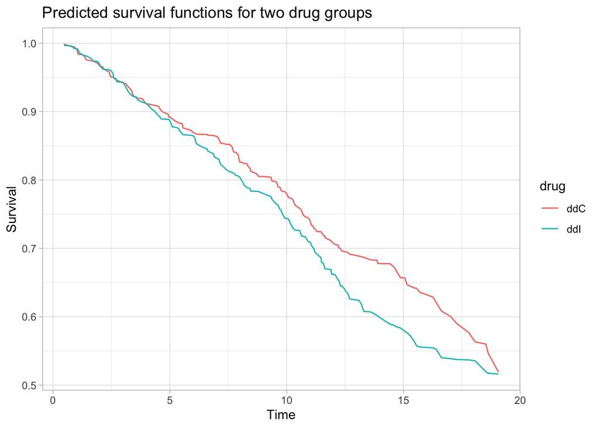

The average survival curves for the two drug groups shows that the survival probabilities of group ddI and ddC are very close to each other at early stages. However, the survival probability of group ddC will be overall higher that group ddI later, which implies that the effect of ddC is better than ddI.

### Cross-validation: AUC and BS for `aids` dataset (MCEM, Bayesian)

We now perform cross-validation for MCEM and Bayesian methods to calculate AUS and BS for the `aids` dataset.

```r
cv.dat <- create_cv(long.dat, surv.dat) ## create 10 cv dataset repeats
st <- c(2, 4, 6) ## starting time
dt <- c(1, 1.5) ## prediction time window
mcem.auc.bs.mean <- matrix(0, length(st)*length(dt), 2)
stan.auc.bs.mean <- matrix(0, length(st)*length(dt), 2)
```

```r
kable(mcem.auc.bs.mean, caption = "Means of AUC and BS from MCEM")
```

Means of AUC and BS from MCEM

| starting.time | prediction.window | Est.AUC | Est.BS |
| --- | --- | --- | --- |
| 2 | 1.0 | 0.7551672 | 0.0363612 |
| 2 | 1.5 | 0.7306602 | 0.0524859 |
| 4 | 1.0 | 0.6562835 | 0.0224572 |
| 4 | 1.5 | 0.6014953 | 0.0385105 |
| 6 | 1.0 | 0.8706842 | 0.0265216 |
| 6 | 1.5 | 0.8097124 | 0.0409757 |

```r
kable(stan.auc.bs.mean, caption = "Means of AUC and BS from Bayesian")
```

Means of AUC and BS from Bayesian

| starting.time | prediction.window | Est.AUC | Est.BS |
| --- | --- | --- | --- |
| 2 | 1.0 | 0.7408102 | 0.0366126 |
| 2 | 1.5 | 0.7203974 | 0.0528425 |
| 4 | 1.0 | 0.6589896 | 0.0223717 |
| 4 | 1.5 | 0.6084549 | 0.0382911 |
| 6 | 1.0 | 0.8762772 | 0.0265153 |
| 6 | 1.5 | 0.8144162 | 0.0409752 |

### Cross-validation: AUC and BS for `aids` dataset (RSF)

```r
kable(RSF.auc.bs.mean, caption = "Means of AUC and BS from RSF")
```

Means of AUC and BS from RSF

| st | dt |  |  |
| --- | --- | --- | --- |
| 2 | 1.0 | 0.4082616 | 0.0390267 |
| 2 | 1.5 | 0.4716953 | 0.0561725 |
| 4 | 1.0 | 0.5190351 | 0.0229167 |
| 4 | 1.5 | 0.5613718 | 0.0394542 |
| 6 | 1.0 | 0.6028638 | 0.0288582 |
| 6 | 1.5 | 0.5746569 | 0.0450013 |

### Simulation: evaluate correctness of MCEM and Bayesian methods

Using our simulation function from the R package, we can check the methods. We create 10 independent simulated datasets per method.

#### MCEM method results

```r
## Simulation for MCEM
simulation.MCEM = sim.MCEM(sim.num = 10, max.iter = 10, progress = TRUE)
```

```r
kable(simulation.MCEM, caption = "MCEM Simulation Results")
```

MCEM Simulation Results

| Parameter | TrueVal | Estimate | StdDev |
| --- | --- | --- | --- |
| beta0 | 20.0 | 19.9870749 | 0.0906790 |
| beta1 | -1.0 | -0.9997056 | 0.0078919 |
| beta | -4.0 | -3.9184908 | 0.1377484 |
| sigma_u | 2.0 | 2.0035154 | 0.0693187 |
| sigma_e | 1.0 | 0.9996379 | 0.0308322 |
| logh0 | -2.0 | -1.3358545 | 0.4579506 |
| gamma | -1.0 | -0.9638415 | 0.2455433 |
| alpha | -0.2 | -0.1927232 | 0.0336359 |

All the estimates of parameters (except $logh_0$) are very close to their true values, which validate the correctness of MCEM method.

#### Bayesian method results

```r
simulation.Bayesian = sim.Bayesian(sim.num = 10)
```

```r
kable(simulation.Bayesian, caption = "Bayesian Simulation Results")
```

Bayesian Simulation Results

| Parameter | TrueVal | Estimate | StdDev | StdDev_hat | Coverage |
| --- | --- | --- | --- | --- | --- |
| beta[1] | 20.0 | 19.9842446 | 0.0940013 | 0.1240703 | 1.0 |
| beta[2] | -1.0 | -1.0026690 | 0.0054845 | 0.0050671 | 1.0 |
| beta[3] | -4.0 | -3.9191871 | 0.1386823 | 0.1905192 | 1.0 |
| sigma_u | 2.0 | 2.0108993 | 0.0724766 | 0.0687624 | 1.0 |
| sigma_e | 1.0 | 1.0003313 | 0.0302080 | 0.0204168 | 0.8 |
| logh0 | -2.0 | -2.0987897 | 0.1181432 | 0.1270253 | 0.8 |
| gamma[1] | -1.0 | -0.9641972 | 0.2474274 | 0.1880220 | 0.9 |
| alpha | -0.2 | -0.1973920 | 0.0105470 | 0.0152934 | 1.0 |

All the estimates are very close to the true values of paramters and the root-mean-square errors are close to standard deviations, which validate the correctness of Bayesian method.

# Discussion

## Main conclusion from MCEM and Bayesian results

(1). At baseline, the expected value of CD4 count is 10.2 (9.43, 10.9), for a AZT-intolerant patient receiving zalcitabine with no previous AIDS diagnosis at study entry.

(2). The expected change of CD4 count was -0.17 (-0.19, -0.15) when the observed time increased by one month, for the same patient.

(3). When a patient is treated with didanosine, his expected CD4 count will be higher compared with another patient treated with zalcitabine, given the same observed time, previous AIDS diagnosis, AZT tolerance status, and random effect: : 0.45 (-0.32, 1.20).

(4). When a patient has previous opportunistic infection (AIDS diagnosis) at study entry, his/her expected CD4 count will be lower, compared with another patient without previous infection, given the same observed time, treatment drug, AZT tolerance status and random effect: -4.71 (-5.68, -3.74).

(5). When a patient has AZT failure, his expected CD4 count will be lower, compared with another AZT-intolerant patient, given the same observed time, treatment drug, AIDS diagnosis and random effect: -0.31 (-1.27, 0.60).

(7). The latent CD4 count is negatively associated with hazard function. The estimated log hazard ratio is -0.28 (-0.35, -0.22).

## Limitations

Below are some advantages and disadvanges of the three methods.

### MCEM algorithm

Advantages: (1). Likelihood-based method, therefore robust and consistent; (2). Fairly stable

Disadvantages: (1). Computationally intensive, especially for M-step; (2). Difficult to implement

### Bayesian method

Advantages: (1). Likelihood-based method, therefore robust and consistent; (2). Fast computational speed; (3). Easy to implement

Disadvantages: (1). Credible interval isn’t necessarily equal to confidence interval; (2). Depends on prior

### RSF

Advantages: (1). Extremely fast speed; (2). Easy to implement

Disadvantages: (1). Inaccurate (in estimation of AUC and BS); (2). Difficult to interpret; (3). No current method for joint modeling of longitudinal data and survival data

## Future direction

For MCEM method, it is very hard to directly optimize the objective function in M-step. One possible way is to approximate the objective function by Taylor expansion and find a majorization function.

Moreover, we can generalize the baseline hazard function into a non-constant function $h_0(t)$. This will convert our model into a semi-parametric model. One simple way is to approximate baseline hazard function by step function.

As for machine learning methods, there is no existing method to jointly model longitudinal data and survival data. One way is to construct neural networks. We first construct neural networks to model the longitudinal mean. With predicted longitudinal mean, we model survival data with neural networks. To avoid two-step estimation, loss functions for two neural networks can be minimized jointly, which, however, may require more data to converge. Another way is to apply offline reinforcement learning. In this setting, we can treat the drug as action and survival status at different time as state.

# References

1. Li, Kan, and Sheng Luo. “Dynamic Predictions in Bayesian Functional Joint Models for Longitudinal and Time-to-Event Data: An Application to Alzheimer’s Disease.” Statistical Methods in Medical Research 28, no. 2 (2017): 327–42. https://doi.org/10.1177/0962280217722177
2. Ye and Wu. “Two-step and likelihood methods for joint models of longitudinal and survival data.” Communications in Statistics - Simulation and Computation Vol 46, Issue 8 (2017): 6019-6033. https://doi.org/10.1080/03610918.2016.1188208
3. Serrat et al. “Frequentist and Bayesian approaches for a joint model for prostate cancer risk and longitudinal prostate-specific antigen data.” Journal of Applied Statistics: 42(6). https://www.tandfonline.com/doi/abs/10.1080/02664763.2014.999032
4. Vignette: http://www.drizopoulos.com/vignettes/multivariate\%20joint\%20models
5. Vignette: http://www.drizopoulos.com/vignettes/dynamic_predictions